# Ridge Regression

The library `ggplot` is used for plotting (use `install.packages()` if the packages are not available):

```r
library(ggplot2)
library(reshape2)
library(AmesHousing)

# install.packages("ggplot2")
# install.packages("reshape2")
# install.packages("AmesHousing")
```

## Import Dataset and View Table:

We will be using the `AmesHousing` dataset.

Ames is a city in the US state of Iowa. The Ames housing dataset consists 2930 observations of the sale of houses in Ames. There are a large number of explanatory variables (23 nominal, 23 ordinal, 14 discrete and 20 continuous) that are involved in assessing home values.

```r
ames = AmesHousing::make_ames()
head(ames)
print(nrow(ames))
```

A tibble: 6 × 81

| MS_SubClass <fct> | MS_Zoning <fct> | Lot_Frontage <dbl> | Lot_Area <int> | Street <fct> | Alley <fct> | Lot_Shape <fct> | Land_Contour <fct> | Utilities <fct> | Lot_Config <fct> | ⋯ | Fence <fct> | Misc_Feature <fct> | Misc_Val <int> | Mo_Sold <int> | Year_Sold <int> | Sale_Type <fct> | Sale_Condition <fct> | Sale_Price <int> | Longitude <dbl> | Latitude <dbl> |
| --- | --- | --- | --- | --- | --- | --- | --- | --- | --- | --- | --- | --- | --- | --- | --- | --- | --- | --- | --- | --- |
| One_Story_1946_and_Newer_All_Styles | Residential_Low_Density | 141 | 31770 | Pave | No_Alley_Access | Slightly_Irregular | Lvl | AllPub | Corner | ⋯ | No_Fence | None | 0 | 5 | 2010 | WD | Normal | 215000 | -93.61975 | 42.05403 |
| One_Story_1946_and_Newer_All_Styles | Residential_High_Density | 80 | 11622 | Pave | No_Alley_Access | Regular | Lvl | AllPub | Inside | ⋯ | Minimum_Privacy | None | 0 | 6 | 2010 | WD | Normal | 105000 | -93.61976 | 42.05301 |
| One_Story_1946_and_Newer_All_Styles | Residential_Low_Density | 81 | 14267 | Pave | No_Alley_Access | Slightly_Irregular | Lvl | AllPub | Corner | ⋯ | No_Fence | Gar2 | 12500 | 6 | 2010 | WD | Normal | 172000 | -93.61939 | 42.05266 |
| One_Story_1946_and_Newer_All_Styles | Residential_Low_Density | 93 | 11160 | Pave | No_Alley_Access | Regular | Lvl | AllPub | Corner | ⋯ | No_Fence | None | 0 | 4 | 2010 | WD | Normal | 244000 | -93.61732 | 42.05125 |
| Two_Story_1946_and_Newer | Residential_Low_Density | 74 | 13830 | Pave | No_Alley_Access | Slightly_Irregular | Lvl | AllPub | Inside | ⋯ | Minimum_Privacy | None | 0 | 3 | 2010 | WD | Normal | 189900 | -93.63893 | 42.06090 |
| Two_Story_1946_and_Newer | Residential_Low_Density | 78 | 9978 | Pave | No_Alley_Access | Slightly_Irregular | Lvl | AllPub | Inside | ⋯ | No_Fence | None | 0 | 6 | 2010 | WD | Normal | 195500 | -93.63893 | 42.06078 |

```
[1] 2930
```

## Modelling the Sale Price

### Standard OLS

Let's predict the sale price (`Sale_Price`) based on two independent variables: the above ground living area (`Gr_Liv_Area`) and the total number of rooms above ground (`TotRms_AbvGrd`).

These variables are highly correlated:

```
[1] 0.8077721
```

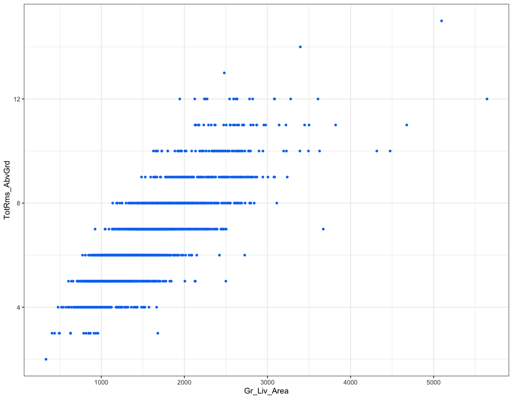

```r
options(repr.plot.width = 18, repr.plot.height = 14)

ggplot(ames, aes(x = Gr_Liv_Area, y =TotRms_AbvGrd)) + geom_point(color='#0578f2', size = 2.5) +
    theme_bw(base_size = 20)

print(cor(ames$Gr_Liv_Area, ames$TotRms_AbvGrd))
```

Fitting a regression model using both these variables yields:

```r
lm(Sale_Price ~ Gr_Liv_Area + TotRms_AbvGrd, data = ames)
```

[output not shown]

Note how `Gr_Liv_Area` has a positive coefficient (139.4), but `TotRms_AbvGrd` has a negative coefficient (-11025.9). This suggests that one variable has a positive effect and the other has a negative effect on the sale price.

However, if we fit a regression just using each individual variable:

```r
lm(Sale_Price ~ Gr_Liv_Area, data = ames)

lm(Sale_Price ~ TotRms_AbvGrd, data = ames)
```

```
Call:
lm(formula = Sale_Price ~ Gr_Liv_Area, data = ames)

Coefficients:
(Intercept)  Gr_Liv_Area
    13289.6        111.7
```

```
Call:
lm(formula = Sale_Price ~ TotRms_AbvGrd, data = ames)

Coefficients:
  (Intercept)  TotRms_AbvGrd
        18665          25164
```

They both have positive effects on the sale price. This occurred because they are both highly correlated.

### Ridge Regression

```r
X = cbind(rep(1, 2930), ames$Gr_Liv_Area, ames$TotRms_AbvGrd) # design_matrix
y = ames$Sale_Price # the dependent variable
```

Next we implement an `R` function that can compute the coefficients $\beta_0, \beta_1, \ldots, \beta_p$ using the Ridge regression solution

$$ \underline{\hat{\beta}} = (\mathrm{X}^\top\mathrm{X} + \lambda \mathrm{I})^{-1} \mathrm{X}^{\top} \underline{y}. $$

```r
get_ridge_coeffs = function(X, y, lambda) {
    matrix_inverse = solve(t(X) %*% X + lambda * diag(3))
    output = matrix_inverse %*% t(X) %*% y
    return(output)
}
```

Note that if $\lambda = 0$, then we recover the coefficients from using `lm()` above:

```r
get_ridge_coeffs(X, y, lambda = 0)
```

A matrix: 3 × 1 of type dbl

| 42767.6361 |
| --- |
| 139.4075 |
| -11025.8696 |

Let's compute a bunch of coefficients for different $\lambda$ values:

```r
lambda_vals = seq(1000, 40000, length.out = 200)

ridge_coeffs = get_ridge_coeffs(X, y, lambda = lambda_vals[1])

for (i in 2:200) {
    ridge_coeffs = cbind(ridge_coeffs, get_ridge_coeffs(X, y, lambda = lambda_vals[i]))
}
```

Let's plot these coefficients:

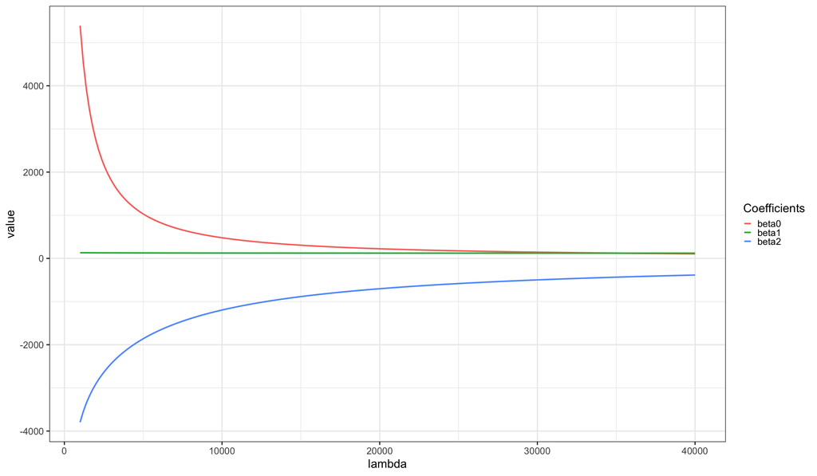

```r
options(repr.plot.width = 24, repr.plot.height = 14)

coeff_dataframe = as.data.frame(cbind(lambda_vals, t(ridge_coeffs)))
colnames(coeff_dataframe) = c('lambda', 'beta0', 'beta1', 'beta2')

tdata = melt(coeff_dataframe, id.vars = 'lambda')

ggplot(tdata, aes(x = lambda, y = value, col = variable)) + geom_line(linewidth = 1.5) +
        theme_bw(base_size = 25) + labs(color='Coefficients')
```